# Assignment: Course Project 1

Thiago Augusto Cardoso

June 8, 2016

For producing a fully reproducible document, first we load the required libraries and set the working directory

```r
## load required libraries
library(dplyr)
library(RCurl)
library(rio)
library(lubridate)
library(ggplot2)

## set working directory
setwd('/home/mascc2/coursera/reproducible-research')
```

In a second step, we actually download the data from source at [cloud front, acessed in 2016-06-08] (‘https://d396qusza40orc.cloudfront.net/repdata%2Fdata%2Factivity.zip’) and store in a data.frame

```r
## download data and store in a variable
activity<-data.frame()
activity<-import('https://d396qusza40orc.cloudfront.net/repdata%2Fdata%2Factivity.zip')
```

For assuring that the data actually loaded properly we echo the variable

```r
head(activity)
```

```
##   steps       date interval
## 1    NA 2012-10-01        0
## 2    NA 2012-10-01        5
## 3    NA 2012-10-01       10
## 4    NA 2012-10-01       15
## 5    NA 2012-10-01       20
## 6    NA 2012-10-01       25
```

## 1. We also load the data with the dplyr package for easier filtering and aggregation.

```r
## load file
activitydplyr<-tbl_df(activity)
```

## Then we procede with the aggregation to have the number of steps by date.

```r
## generate the number of steps per day
stepsbydate<-aggregate(steps ~ date, activitydplyr,sum,na.rm=TRUE)
```

## 2. Now we generate the histogram of steps per day according to question number 2

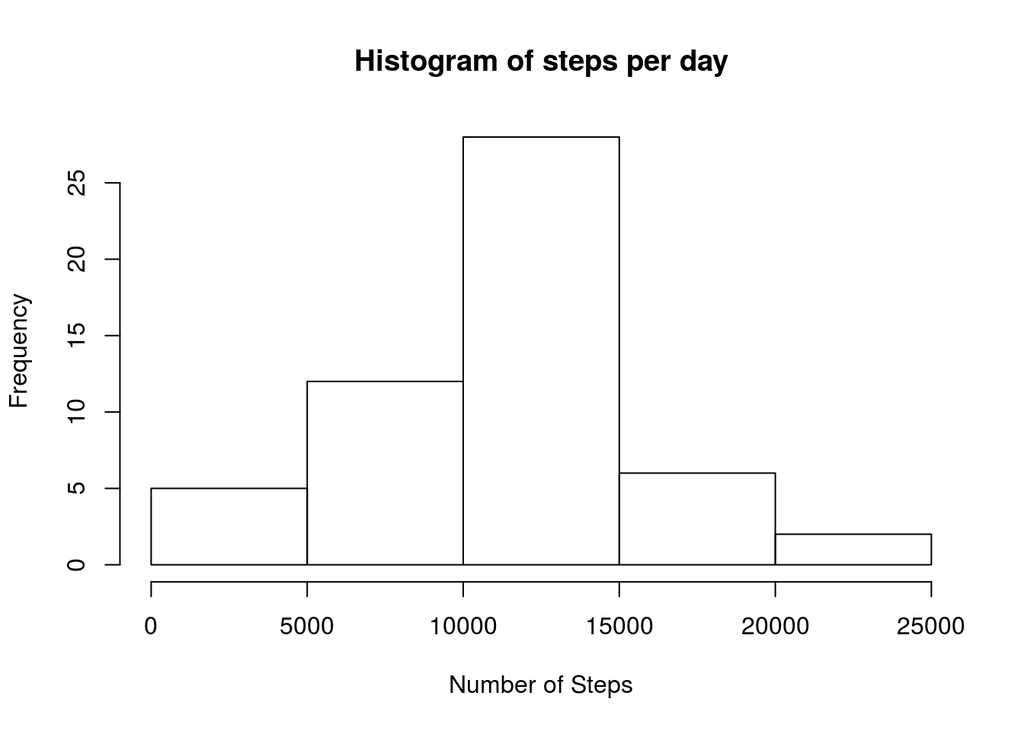

```r
## generate histogram of steps per day
hist(stepsbydate$steps,main='Histogram of steps per day',xlab='Number of Steps')
```

## 3. Now we generate the mean and median number of steps taken each day according to question number 3

Calculating the mean steps per day

```r
## take the mean number of steps taken each day
meanstepsbydate <-aggregate(steps ~ date, activitydplyr,mean,na.rm=TRUE)
```

```r
meanstepsbydate
```

```
##          date      steps
## 1  2012-10-02  0.4375000
## 2  2012-10-03 39.4166667
## 3  2012-10-04 42.0694444
## 4  2012-10-05 46.1597222
## 5  2012-10-06 53.5416667
## 6  2012-10-07 38.2465278
## 7  2012-10-09 44.4826389
## 8  2012-10-10 34.3750000
## 9  2012-10-11 35.7777778
## 10 2012-10-12 60.3541667
## 11 2012-10-13 43.1458333
## 12 2012-10-14 52.4236111
## 13 2012-10-15 35.2048611
## 14 2012-10-16 52.3750000
```

[output cut: 39 more lines]

Calculating the median steps per day

```r
medianstepsbydate <-aggregate(steps ~ date, activitydplyr,median,na.rm=TRUE)
```

```r
medianstepsbydate
```

```
##          date steps
## 1  2012-10-02     0
## 2  2012-10-03     0
## 3  2012-10-04     0
## 4  2012-10-05     0
## 5  2012-10-06     0
## 6  2012-10-07     0
## 7  2012-10-09     0
## 8  2012-10-10     0
## 9  2012-10-11     0
## 10 2012-10-12     0
## 11 2012-10-13     0
## 12 2012-10-14     0
## 13 2012-10-15     0
## 14 2012-10-16     0
```

[output cut: 39 more lines]

## 4. Times series plot of the average number of steps taken each day

Generating the time series plot

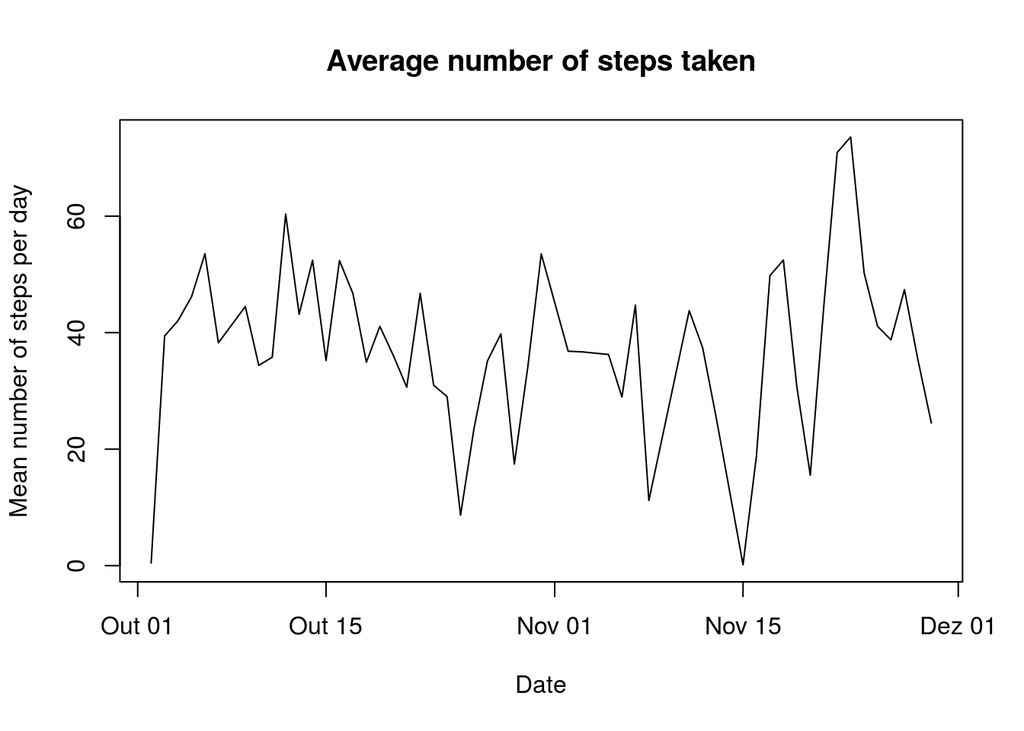

```r
meanstepsbydate$date<-as.Date(meanstepsbydate$date)
plot(meanstepsbydate$date,meanstepsbydate$steps,xlab='Date',ylab = 'Mean number of steps per day',main="Average number of steps taken",type='l')
```

Selecting the maximum number of steps on average

```r
meanstepsbydatedplyr<-tbl_df(meanstepsbydate)
max<-head(arrange(meanstepsbydatedplyr,desc(steps)),1)
max
```

```
## Source: local data frame [1 x 2]
##
##         date    steps
##       <date>    <dbl>
## 1 2012-11-23 73.59028
```

## 6. Code to describe and show a strategy for imputing missing data

Show the number of missing cases

```r
missingcases <- sum(is.na(activitydplyr$steps))
missingcases
```

```
## [1] 2304
```

Inputting missing cases with the mean

```r
activitynonna <- activitydplyr
activitynonna$steps[is.na(activitynonna$steps)] <- mean(activitynonna$steps, na.rm=TRUE)
activitynonnaperday <- aggregate(steps ~ date, data=activitynonna, sum, na.rm=TRUE)
activitynonna
```

```
## Source: local data frame [17,568 x 3]
##
##      steps       date interval
##      <dbl>      <chr>    <int>
## 1  37.3826 2012-10-01        0
## 2  37.3826 2012-10-01        5
## 3  37.3826 2012-10-01       10
## 4  37.3826 2012-10-01       15
## 5  37.3826 2012-10-01       20
## 6  37.3826 2012-10-01       25
## 7  37.3826 2012-10-01       30
## 8  37.3826 2012-10-01       35
## 9  37.3826 2012-10-01       40
## 10 37.3826 2012-10-01       45
## ..     ...        ...      ...
```

```r
str(activitynonna)
```

```
## Classes 'tbl_df', 'tbl' and 'data.frame':    17568 obs. of  3 variables:
##  $ steps   : num  37.4 37.4 37.4 37.4 37.4 ...
##  $ date    : chr  "2012-10-01" "2012-10-01" "2012-10-01" "2012-10-01" ...
##  $ interval: int  0 5 10 15 20 25 30 35 40 45 ...
```

## 7. Histogram of the total number of steps taken each day after missing values are imputed

Generating the histogram

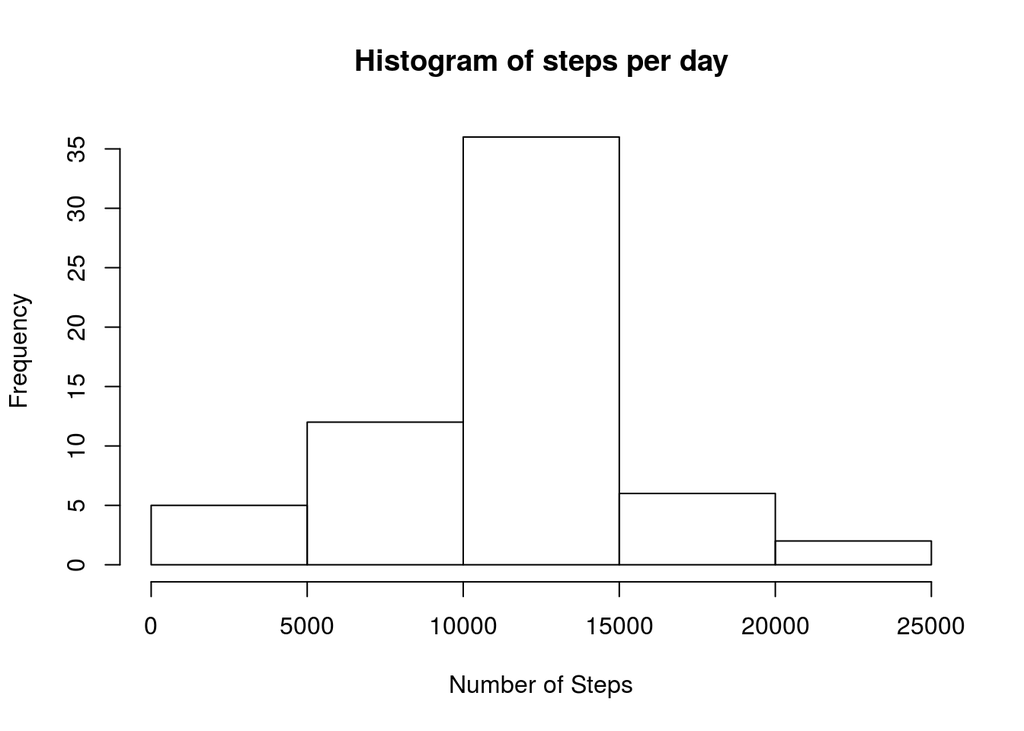

```r
hist(activitynonnaperday$steps,main='Histogram of steps per day',xlab='Number of Steps')
```

Create a function to check if there is a weekday

```r
is_weekday <-function(date){
        if(wday(date) %in% c(1,7)) result<-"weekend"
        else
                result<-"weekday"
        result
}
```

create the variable weekday and check how many weekdays

```r
activitynonna <- mutate(activitynonna,date=ymd(date)) %>% mutate(weekday=sapply(date,is_weekday))

table(activitynonna$weekday)
```

```
##
## weekday weekend
##   12960    4608
```

plot the graph

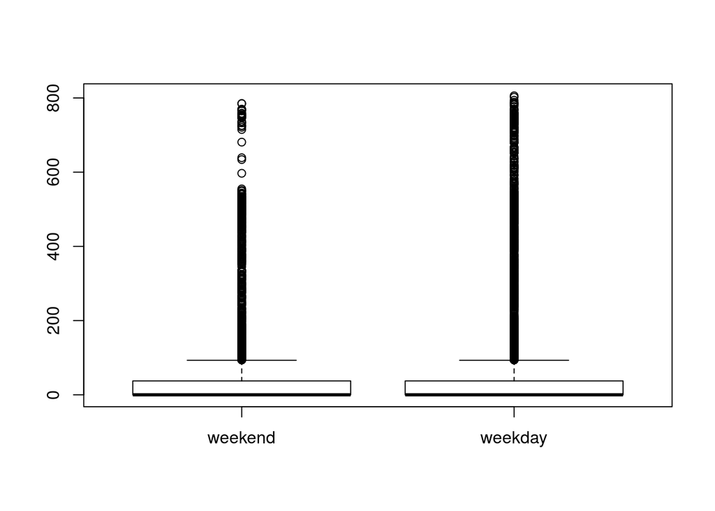

```r
daily_patterns <- activitynonna %>% mutate(weekday=factor(weekday,levels=c("weekend","weekday"))) %>%
group_by(interval,weekday)

plot(daily_patterns$weekday,daily_patterns$steps)
```